# pyXsurf - a Python library for analysis of surface data

# Outline

- Surface Metrology and AFM
- What is pyXsurf, and why you need it
- Some examples

## Surface Metrology Data for AFM and Other Instruments

AFM data are (most of the times) surface or profile data.

Surface and Profile data (I will consider them as a subset) are of general interest in almost any field of science and technology, from optics, to microscopy, to material science and biology.

Many operations are common to different disciplines and instruments.

Data represent a map over a 2D grid (or more in general a set of points in the 3D space), where elevation, intensity, or other quantities are expressed as a function of 2D position, identified on surface by its relation with coordinate axis.

[figure not shown]

A set of operations (many of which are common in different disciplines, e.g. leveling, feature recognition, profile extraction) are performed on data.

Furthermore:

- Automatic metrology systems can collect large sets of correlated data.
- Several related maps (e.g. different instruments or different samplings) can be correlated.
- There might be automation/interaction with other instruments or sensors.

## Common Solutions and Tools

### OEM Software

Usually provided with the instrument. Typically GUI-based:

- quick and easy, however can be a problem for consistency (e.g. change of color scale, different leveling procedures).
- It needs a skilled technician to manage settings, analysis and macros. Hard-to-acquire and instrument-specific skills.
- limited or no access to code to add functionalities (*)
- not scalable to large number of data (*)

(*) Many of these tools implement some form of scripting (often Python based) or macro procedures, internally (scripting engine embedded in software) or externally (access to internal functions given through APIs od DLLs).

### Open Source Solutions

[output not shown]

### In Academy

[figure not shown]

Everybody writes their own software:

- from scratch
- in their favorite language
- keeps it secret (writing it with no comments and possibly backwards).

There are anyway some good solution, but quite low-level or in languages for initiated (e.g. TOPO library in IDL).

#### The Python programming language impact on science

In many fields of science, the Python programming language, with its approach aimed at reusability, inverted this tendency: in the last years, several Python packages, tools and libraries emerged and established themselves as standard tools, bringing the language to be one of the most popular in science, if not the most popular.

The result is an enormous base of users.

High quality libraries for practically any field of science.

Python is likely also the most commonly used language for scripting of surface-metrology instruments proprietary software.

[figure not shown]

However, to the knowledge of the author, there is not an universally recognized framework in any language and especially not in Python.

Python has good facility to deal with multidimensional arrays, but it lack the coordination with axis (It basically treat everything as a matrix).

# pyXsurf

The library was created during research on X-ray mirrors (X-ray mirrors are characterized at all wavelength from AFM to LTP, meaning from 1 um to meters scan size, profile or surface).

The `pyXsurf` library consists in a set of core routines and classes, with a quite uniform and well defined interface, which can internally handle coordinate transformations, resulting in much more intuitive operations and enabling complex actions on data compared to pure Python.

## Advantages of the approach

Python offers:

- Numerous facilities and tools available for software maintenance and documentation: tests, API documentation;
- Solid development environments, debugging tools, package managers;
- Reusable code;
- Different interfaces (command line, scripts, notebooks, graphical interface or integration with existing code, interactive code to share online), making it the ideal language for an easily-maintainable general-purpose project.
- Huge amount of high-quality science libraries;
- Highly reusable code;

## Structure of the library

The library is mostly made of classes, of which the most important is Data2D, representing a measured surface. A Data2D object p1 can be created by passing data, e.g.:

```python
from pySurf.data2D_class import Data2D

D = Data2D(data,x,y,units=['um','um','nm'],scale=[1,1,1.e9],name=os.path.basename(f))  # data,x,y previously read from .dat file
```

We can do a basic plot.

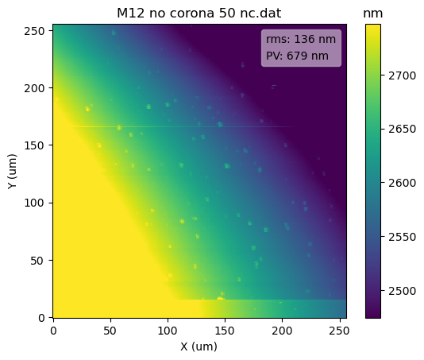

```python
D.plot(stats=1)
```

The units are already set up. Several options are available for customization, `plot` method follows standard `plt.plot` interface, the returned plot is an `plt.Axes` object, modifiable with usual commands.

Leveling can be performed with a number of options to level to same or different orders in x and y, or by line along each axis:

```python
D.level?
```

```
Signature: D.level(*args, **kwargs)
Docstring:
level_data(data, x=None, y=None, degree=1, axis=None, byline=False, fit=False, *args, **kwargs)
Use RA routines to remove degree 2D legendres or levellegendre if leveling by line.

    Degree can be scalar (it is duplicated) or 2-dim vector. must be scalar if leveling by line. Note the important difference between e.g. ``degree = 2`` and
      ``degree = (2,2)``. The first one uses degree as total degree, it expands then to xl,yl = [0,1,0,1,2,0],[0,0,1,1,0,2]. The second

    leveling by line (controlled by axis keyword) also handle nans.
    x and y are not used, but maintained for interface consistency.
    fit=True returns fit component instead of residuals

File:      c:\users\kovor\documents\python\pyxtel\source\pysurf\data2d_class.py
Type:      method
```

Leveling operations return a new object, Commmands can be chained, here `plot` method is called on the object resulting from `D.level()` (default remove plane):

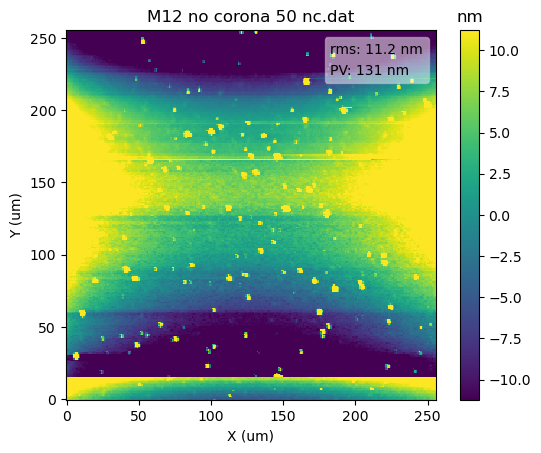

```python
plt.figure(2)
D.level().plot(stats=1) # remove plan, stats controls the info box
```

Statistical functions (same interface as `plt.hist()`):

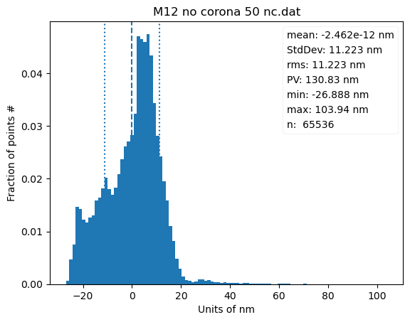

```python
D.level().histostats();  # data after plane removal
```

The distribution is quite irregular, we can look for a more advanced leveling.

Results can be assigned to variables, here `Dl` is the result of removing a plan and then second order Legendre in horizontal direction for each line is removed:

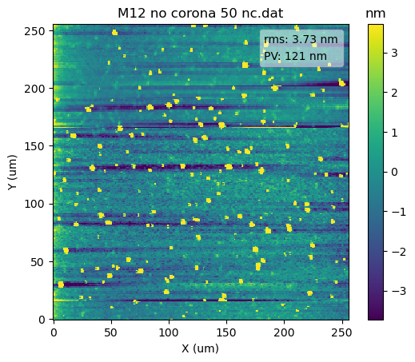

```python
plt.figure(3)
Dl = D.level().level(2,axis=1)
Dl.plot(stats=1)
```

Several common operations, remove outliers:

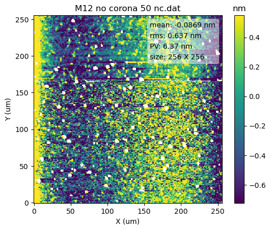

```python
plt.figure()
Dl.remove_outliers(nsigma =3).plot()
```

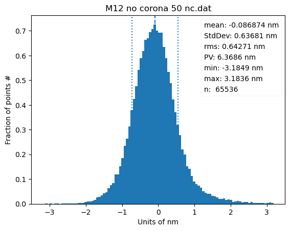

```python
Dl.remove_outliers(nsigma=3).histostats();
```

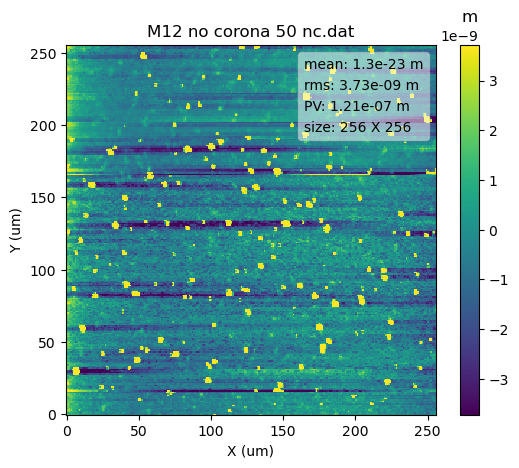

```python
Dl.plot()
```

We can try to remove outliers and level again by line (brings very close to data intrinsic errors):

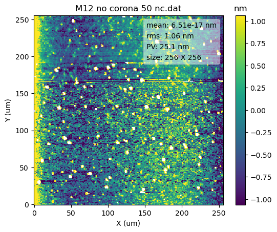

```python
Dl = D.level().level(2,axis=1).remove_outliers(nsigma =3).level(2,axis=1)

Dl.plot()
```

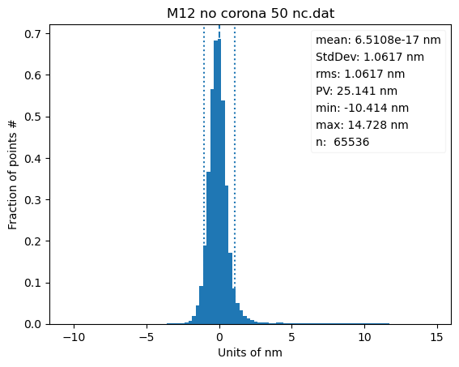

```python
Dl.histostats();
```

## Profile Extraction

Method `Data2D.extract_profile` profiles can be extracted as `Profile` objects according to different criteria, including interactive mode, by point and click. In this case horizontal profiles are extracted at fixed `y`s.

```python
from pyProfile.profile_class import Profile

ypos = [50,100,150,200]

plist = []  # make a list of profiles

for y in ypos:    # populate the list for the positions in y using `Data2D.extract_profile`.
    plist.append(Profile(*Dl.extract_profile([10,y],[240,y],along=True),name = y))
```

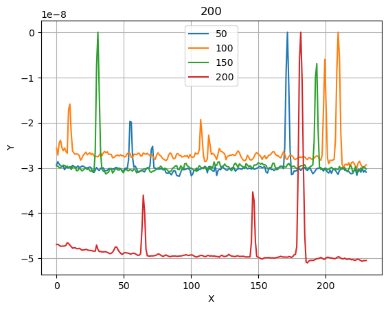

```python
for pp in plist:
    pp.level(zero='top').plot()

plt.grid()
plt.legend(loc=0)
```

## Write complex scripts and make them available as functions

```
WARNING: low limit detected in prange, can cause problems with log color scale.
```

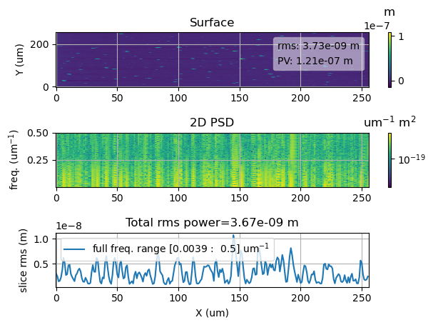

```python
ps = Dl.psd(analysis=True)
```

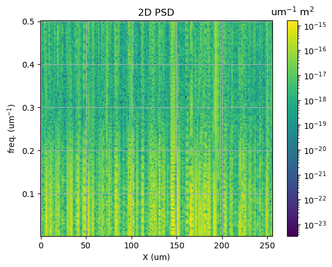

```python
ps.plot()
```

```
No handles with labels found to put in legend.
```

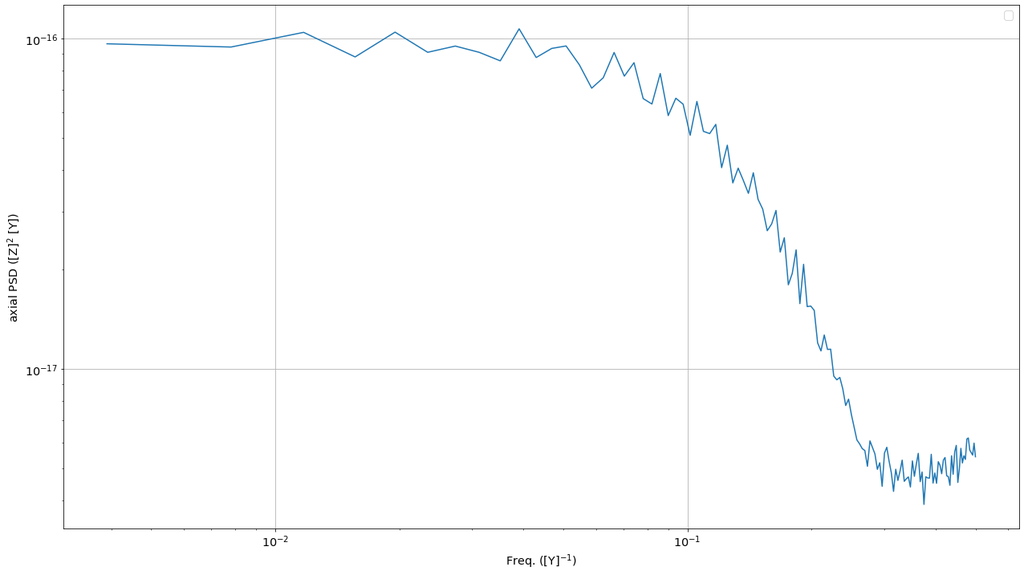

```python
from pyProfile.psd import plot_psd

plot_psd(*ps.avgpsd())
```

## Gallery

Applicable cases in my experience:

- Batch extraction of regions, points or profiles from data, calculation of derived quantities and analysis/visualization as series (e.g. time evolution, thermal and environmental effects).
- Best fit of a surface by scaling of another surface (e.g thin films stress), or combination of multiple ones (e.g.: summing deformations);.
- Comparison of two different surface maps with different sampling or registration;
- Combination and stitching of data larger than a single field. (e.g. uniformity obtained by small maps on larger maps).
- Building data pipelines, or in general all cases where a complex analysis on data needs to be repeated multiple times.
- Integration with existing specific code or analysis tools.

## Fit of Stress in thin films

[figure not shown]

## Alignment of Images with different instruments

[figure not shown]

## Slope Analysis

Methods `.slope` of object `data2d_class.Data2D`, and functions `plot_slope_2D` and `plot_slope_slice` calculate slopes and related statistics.

[figure not shown]

```python
Data2D.slope?
```

```
Signature: Data2D.slope(self, *args, **kwargs)
Docstring:
slope_2D(wdata, x, y, scale=(1.0, 1.0, 1.0))
calculate slope maps in x and y.
    return a couple of maps of type slope,x,y data for x and y slopes respectively.
    Set scale to (dx,dy,1000.) for z in micron, x,y in mm. (?does it mean  1,1,1000?)
File:      c:\users\kovor\documents\python\pyxtel\source\pysurf\data2d_class.py
Type:      function
```

## Fit of Model

In this experiment, a part was measured before and after a process.

## Results of Machining and Optical Performance Simulation

## Extraction of Statistics

[figure not shown]

## Status of the project

- First public appearence, until now a single person project.
- I constantly work on it, as I use it. So this is what dictate my direction, but it can change on user feedback.
- Of course, first thing to make it usable is to have documentation.
- Documentation is available for many functions as docstrings (Python way of automatically generating documentation from comments in code), but is not uniform and not available as external documentation.
- Installation can be (easily) performed manually.

# Contacts

Project page (docs):

Source Code: https://github.com/vincenzooo/pyXsurf

My email: vincenzo.cotroneo@inaf.it

# Acknowledgements

Thanks to my current Institution (Osservatorio Astronomico di Brera, Merate, IT) and the previous one (Center for Astrophysics | Harvard & Smithsonian, Cambridge, MA, USA).

Thanks to the wonderful Python community.